# Fundamentals of machine learning

MACS 30200 University of Chicago

## Evaluating machine learning models

- Want to build generalizable models
- Requires strong performance on held-out or test data
- Need to measure the reliability of the model not solely on the training data

## Training, validation, and test sets

- Split your data into three portions
- Training
- Validation
- Test

## Need for the validation set

- Hyperparameters
- Hyperparameter tuning
- Information leaks
- Only use the test set once, at the end to evaluate the final model

## Simple hold-out validation

- Randomly split the training data one time into two portions
- Works reasonably well if your dataset is large
- If the dataset is small, validation and test sets may have too few observations to fairly judge the model

## K-fold validation

- Portion the training data into K partitions of equal size
- For each partition, train a model on the remaining $K-1$ partitions and evaluate it on the held-out partition
- Average across all $K$ scores to get the final score
- Works well if the metric has large variance for any given training-validation split

## Iterated K-fold validation with shuffling

- Repeat K-fold validation multiple times, with new K partitions each iteration
- Generates more precise estimates in a small dataset
- Computationally intensive

## Things to consider

- Data representativeness
- Arrow of time

## Data preprocessing

- Convert your data to an appropriate tensor of floating-point numbers (or integers)

## Value normalization

- Rescale your data to a standardized range
- Avoid large values or heterogeneous values
- Take small values
- Be homogenous
- Standard practice
- Always calculate normalized values using the training data

## Missing values

- Missingness can be informative
- No explicit `NA` value for neural networks
- Encode missing values as non-meaningful value
- Over time the network will learn that this means missing value

## Feature engineering

- Unnecessary to create hard-coded transformation of features
- Why you should still engineer features
- Engineer features based on your domain expertise

## Feature engineering

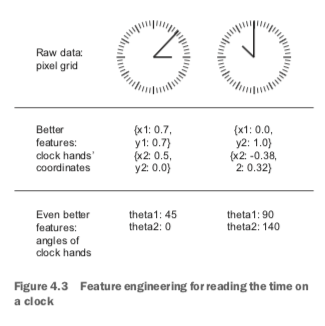

## Overfitting and underfitting

- Tension between optimization and generalization
- Underfitting
- Once generalization stops, model begins to overfit
- Best solution - get more training data
- Artificially constrain the quantity of information retained in your model
- Known as regularization

## Overfitting and underfitting

```r
library(keras)
imdb <- dataset_imdb(num_words = 10000)
c(c(train_data, train_labels), c(test_data, test_labels)) %<-% imdb

vectorize_sequences <- function(sequences, dimension = 10000) {
  # Create an all-zero matrix of shape (len(sequences), dimension)
  results <- matrix(0, nrow = length(sequences), ncol = dimension)
  for (i in 1:length(sequences))
    # Sets specific indices of results[i] to 1s
    results[i, sequences[[i]]] <- 1
  results
}

# Our vectorized training data
x_train <- vectorize_sequences(train_data)
# Our vectorized test data
x_test <- vectorize_sequences(test_data)

# Our vectorized labels
y_train <- as.numeric(train_labels)
y_test <- as.numeric(test_labels)
```

## Reducing the network’s size

- Reduce the size of the model (capacity)
- But not too much
- Best determined via trial and error

## Original model

```r
original_model <- keras_model_sequential() %>%
  layer_dense(units = 16, activation = "relu", input_shape = c(10000)) %>%
  layer_dense(units = 16, activation = "relu") %>%
  layer_dense(units = 1, activation = "sigmoid")

original_model %>% compile(
  optimizer = "rmsprop",
  loss = "binary_crossentropy",
  metrics = c("accuracy")
)
```

## Smaller model

```r
smaller_model <- keras_model_sequential() %>%
  layer_dense(units = 4, activation = "relu", input_shape = c(10000)) %>%
  layer_dense(units = 4, activation = "relu") %>%
  layer_dense(units = 1, activation = "sigmoid")

smaller_model %>% compile(
  optimizer = "rmsprop",
  loss = "binary_crossentropy",
  metrics = c("accuracy")
)
```

## Fit both models

```r
plot_training_losses <- function(losses) {
  loss_names <- names(losses)
  losses <- as.data.frame(losses)
  losses$epoch <- seq_len(nrow(losses))
  losses %>%
    gather(model, loss, loss_names[[1]], loss_names[[2]]) %>%
    ggplot(aes(x = epoch, y = loss, colour = model)) +
    geom_point()
}
```

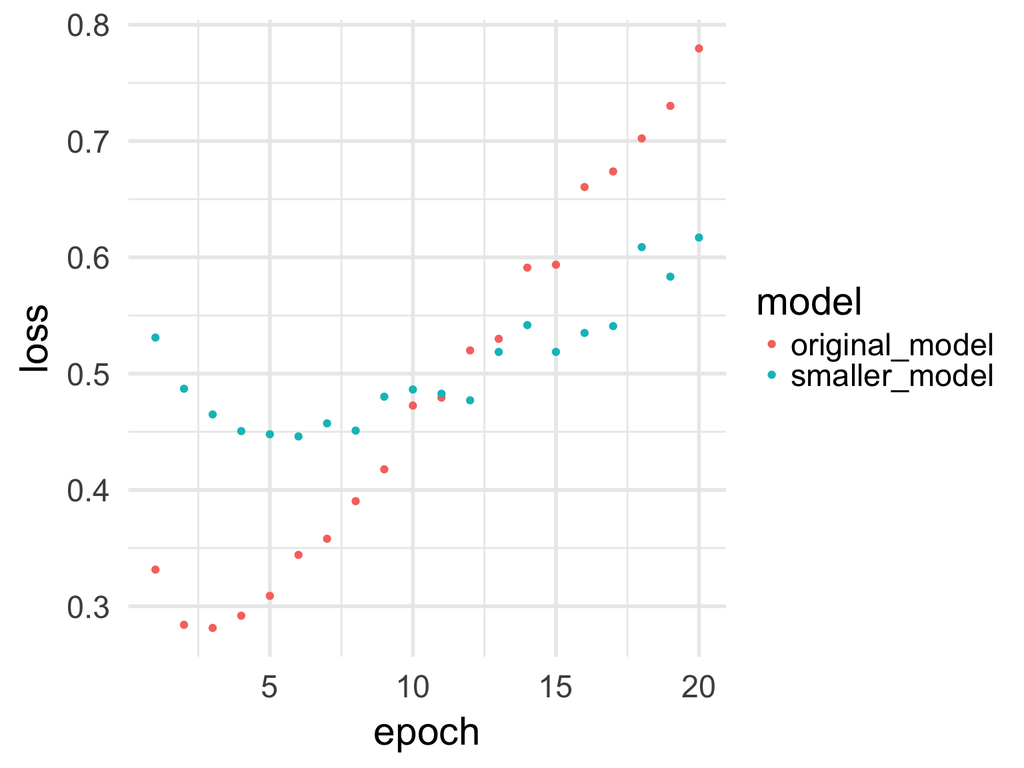

```r
plot_training_losses(losses = list(
  original_model = original_hist$metrics$val_loss,
  smaller_model = smaller_model_hist$metrics$val_loss
))
```

## Bigger model

```r
bigger_model <- keras_model_sequential() %>%
  layer_dense(units = 512, activation = "relu", input_shape = c(10000)) %>%
  layer_dense(units = 512, activation = "relu") %>%
  layer_dense(units = 1, activation = "sigmoid")

bigger_model %>% compile(
  optimizer = "rmsprop",
  loss = "binary_crossentropy",
  metrics = c('acc')
)
```

## Bigger model

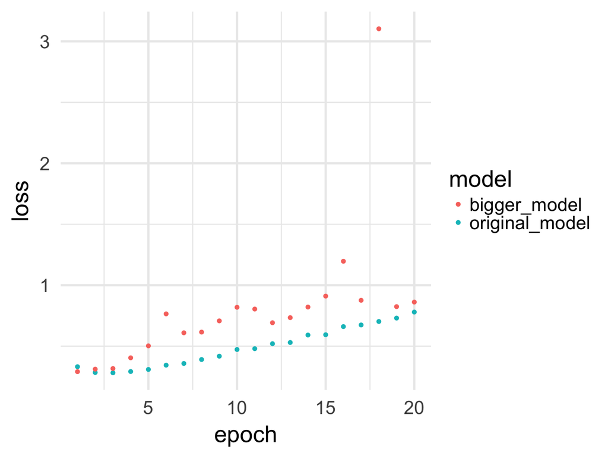

```r
plot_training_losses(losses = list(
  original_model = original_hist$metrics$val_loss,
  bigger_model = bigger_model_hist$metrics$val_loss
))
```

## Training losses

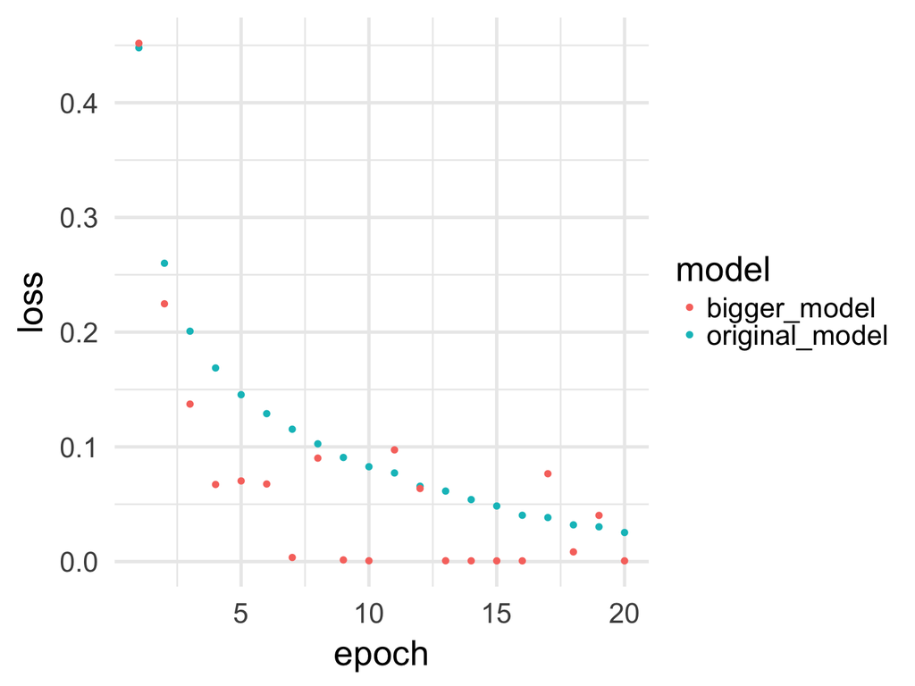

```r
plot_training_losses(losses = list(
  original_model = original_hist$metrics$loss,
  bigger_model = bigger_model_hist$metrics$loss
))
```

## Adding weight regularization

- Occam’s Razor
- Applied to neural networks
- Simple models are distribution of parameters with less variance
- Weight regularization
- L1 regularization
- L2 regularization

## Adding weight regularization

```r
l2_model <- keras_model_sequential() %>%
  layer_dense(units = 16, kernel_regularizer = regularizer_l2(0.001),
              activation = "relu", input_shape = c(10000)) %>%
  layer_dense(units = 16, kernel_regularizer = regularizer_l2(0.001),
              activation = "relu") %>%
  layer_dense(units = 1, activation = "sigmoid")

l2_model %>% compile(
  optimizer = "rmsprop",
  loss = "binary_crossentropy",
  metrics = c("acc")
)
```

## L2 regularization penalty

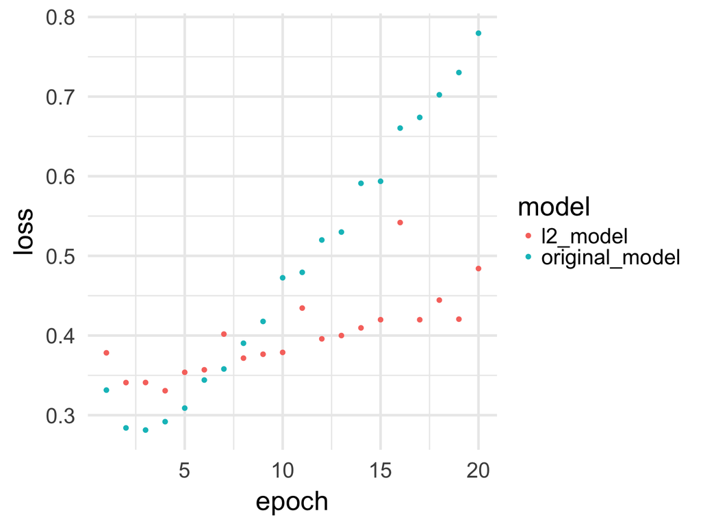

```r
plot_training_losses(losses = list(
  original_model = original_hist$metrics$val_loss,
  l2_model = l2_model_hist$metrics$val_loss
))
```

## Adding dropout

- Randomly set to zero a number of output features of a layer during training
- Dropout rate
- Deliberately remove data from the layer
- Why do this?

## Adding dropout

```r
layer_dropout(rate = 0.5)
```

```r
dpt_model <- keras_model_sequential() %>%
  layer_dense(units = 16, activation = "relu", input_shape = c(10000)) %>%
  layer_dropout(rate = 0.5) %>%
  layer_dense(units = 16, activation = "relu") %>%
  layer_dropout(rate = 0.5) %>%
  layer_dense(units = 1, activation = "sigmoid")

dpt_model %>% compile(
  optimizer = "rmsprop",
  loss = "binary_crossentropy",
  metrics = c("acc")
)
```

```r
dpt_model_hist <- dpt_model %>% fit(
  x_train, y_train,
  epochs = 20,
  batch_size = 512,
  validation_data = list(x_test, y_test)
)
```

## Adding dropout

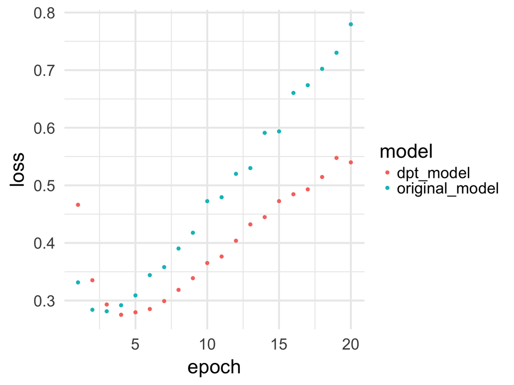

```r
plot_training_losses(losses = list(
  original_model = original_hist$metrics$val_loss,
  dpt_model = dpt_model_hist$metrics$val_loss
))
```

## Universal workflow of machine learning

1. Define the problem and assemble a dataset
2. Choose a measure of success
3. Decide on an evaluation protocol
4. Prepare your data
5. Develop a model that performs better than the baseline
6. Develop a model that overfits
7. Regularize your model and tune your hyperparameters
8. Retrain a final time on all training data and evaluate using the test data